# R Notebook

# An Introduction to Statistical Learning

## 2.3 Lab: Introduction to R

### Basic Commands

Create a vector:

```r
x
```

```
[1] 1 3 5 7
```

Compute the length using the function `length()`:

```r
length(x)
```

[output not shown]

```r
y <- c(2, 4, 6, 8)
```

```r
y
```

```
[1] 2 4 6 8
```

The `ls()` function allow us to look at a list of all of the objects, such as data and functions, that we have saved so far:

```r
ls()
```

```
[1] "x" "y"
```

The `rm()` function can be used to delete any that we don’t want:

```r
rm(y)
```

The `matrix()` function takes a number of inputs:

```r
A <- matrix(data=c(1, 2, 3, 4), nrow=2, ncol=2)
```

```r
A
```

```
     [,1] [,2]
[1,]    1    3
[2,]    2    4
```

Note that we could just as well omit typing `data=`, `nrow=` and `ncol=` in the `matrix()` command above: that is, we could just type:

```r
B <- matrix(c(1, 2, 3, 4), 2, 2)
```

```r
B
```

```
     [,1] [,2]
[1,]    1    3
[2,]    2    4
```

As the example illustrates, by default `R` creates matrices by successively filling in columns. Alternatively, the `byrow=TRUE` option can be used to populate the matrix in order of the rows.

```r
matrix(c(1, 2, 3, 4), 2, 2, byrow=TRUE)
```

```
     [,1] [,2]
[1,]    1    2
[2,]    3    4
```

The `sqrt()` function returns the square root of each element of a vector or matrix.

```r
sqrt(A)
```

```
         [,1]     [,2]
[1,] 1.000000 1.732051
[2,] 1.414214 2.000000
```

The command `x^2` raises each element of x to the power `2`, any powers are possible, including fractional or negative powers.

```r
A^2
```

```
     [,1] [,2]
[1,]    1    9
[2,]    4   16
```

The `rnorm()` function generates a vector of random normal variables, with first argument `n` the sample size. Each time we call this function, we will get a different answer.

Here we create two correlated sets of number, `x` and `y`, and use the `cor()` function to compute the correlation between them.

```r
y = x + rnorm(50, mean=50, sd=0.1)
```

```r
y = x + rnorm(50, mean=50, sd=0.1)
```

```r
cor(x, y)
```

```
[1] 0.9966537
```

By default, `rnorm()` creates standard normal random variable with a `mean=0` and a `standard deviation = 1`. However, the mean and standard deviation can be altered using `mean` and `sd` arguments.

Sometimes, we want our code to reproduce the exact same set of random numbers, we can usee the `set_seed()` function to do this. The `set_seed()` function takes an (arbitrary) integer argument.

```r
set.seed(1303)
```

```r
rnorm(50)
```

```
 [1] -1.1439763145  1.3421293656  2.1853904757  0.5363925179  0.0631929665  0.5022344825 -0.0004167247
 [8]  0.5658198405 -0.5725226890 -1.1102250073 -0.0486871234 -0.6956562176  0.8289174803  0.2066528551
[15] -0.2356745091 -0.5563104914 -0.3647543571  0.8623550343 -0.6307715354  0.3136021252 -0.9314953177
[22]  0.8238676185  0.5233707021  0.7069214120  0.4202043256 -0.2690521547 -1.5103172999 -0.6902124766
[29] -0.1434719524 -1.0135274099  1.5732737361  0.0127465055  0.8726470499  0.4220661905 -0.0188157917
[36]  2.6157489689 -0.6931401748 -0.2663217810 -0.7206364412  1.3677342065  0.2640073322  0.6321868074
[43] -1.3306509858  0.0268888182  1.0406363208  1.3120237985 -0.0300020767 -0.2500257125  0.0234144857
[50]  1.6598706557
```

The `mean()` and `var()` functions can be used to compute the mean and variance of a vector of numbers. Applying `sqrt()` to the output of `var()` will give the standard deviation. Or we can simply use the `sd()` function.

```r
set.seed(3)
```

```r
y <- rnorm(50)
```

```r
mean(y)
```

```
[1] -0.06392194
```

```r
var(y)
```

```
[1] 0.7917457
```

```r
sqrt(var(y))
```

```
[1] 0.8898009
```

```r
sd(y)
```

```
[1] 0.8898009
```

### Graphics

The `plot()` function is the primary way to plot data in `R`. For instance, `plor(x,y)` produces a scatter plot of the numbers in `x` versus the numbers in `y`. There are many additional options that can be passed in to the `plot()` function. For example, passing in the argument `xlab` will result in a label on the $x-axis$.

```r
x <- rnorm(100)
```

```r
y <- rnorm(100)
```

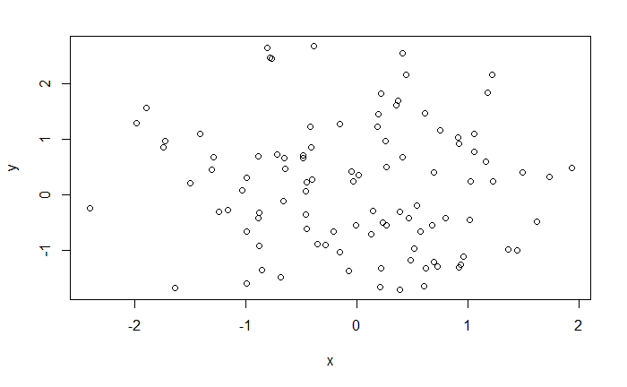

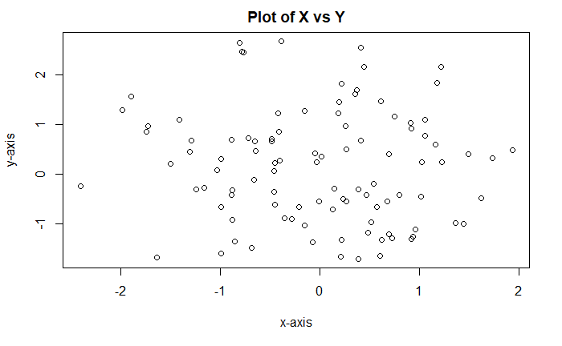

The function `seq()` can be used to create a sequence of numbers. For instance, `seq(a, b)` makes a vector of integers between `a` and `b`. There are many other options: for instances, `seq(0, 1, length = 10)` makes a sequence of `10` numbers that are equally spaced between `0` and `1`.

```r
seq(0, 1, length=10)
```

```
 [1] 0.0000000 0.1111111 0.2222222 0.3333333 0.4444444 0.5555556 0.6666667 0.7777778 0.8888889 1.0000000
```

Typing `3:11` is a shorthand for `seq(3, 11)` for integers arguments

```r
3:11
```

```
[1]  3  4  5  6  7  8  9 10 11
```

```r
seq(-pi, pi, length = 50)
```

```
 [1] -3.14159265 -3.01336438 -2.88513611 -2.75690784 -2.62867957 -2.50045130 -2.37222302 -2.24399475
 [9] -2.11576648 -1.98753821 -1.85930994 -1.73108167 -1.60285339 -1.47462512 -1.34639685 -1.21816858
[17] -1.08994031 -0.96171204 -0.83348377 -0.70525549 -0.57702722 -0.44879895 -0.32057068 -0.19234241
[25] -0.06411414  0.06411414  0.19234241  0.32057068  0.44879895  0.57702722  0.70525549  0.83348377
[33]  0.96171204  1.08994031  1.21816858  1.34639685  1.47462512  1.60285339  1.73108167  1.85930994
[41]  1.98753821  2.11576648  2.24399475  2.37222302  2.50045130  2.62867957  2.75690784  2.88513611
[49]  3.01336438  3.14159265
```

We will now create some more sophisticated plots. The `contour()` functions produces a **contour plot** in order to represent three-dimensional data; it is like a topographical map. It takes three arguments:

- A vector of the `x` values (the first dimension)
- A vector of the `y` values (the second dimension)
- A matrix whose elements correspond to the `z` value (the third dimension) for each pair of (`x`, `y`) coordinates.

```r
y = x
```

```r
f = outer(x, y, function(x, y) cos(y) / (1 + x^2))
```

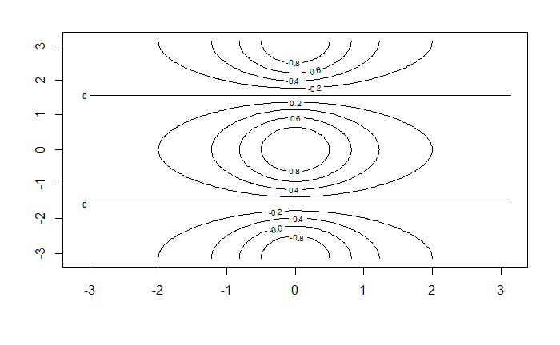

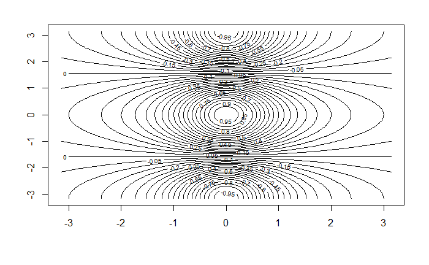

```r
fa <- (f - t(f))/2
```

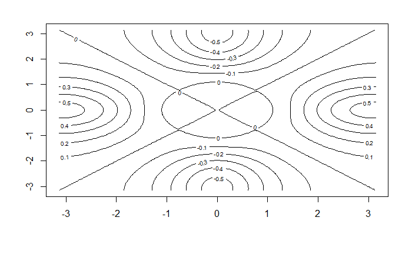

The `image()` function works the same way as `contour()`, except that it produces a color-coded plot whose colors depend on the `z` value. This is known as a **heatmap**, and is sometimes used to plot temperature in weather forecast.

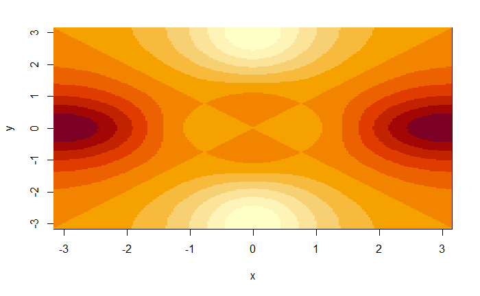

Alternatively, `perps()` can be used to produce a three-dimensional plot. The arguments `theta` and `phi` control the angles at which the plot is viewed.

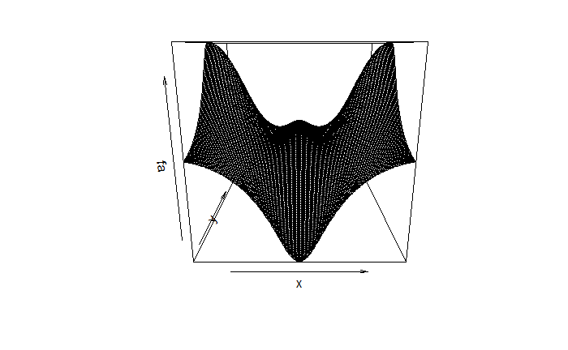

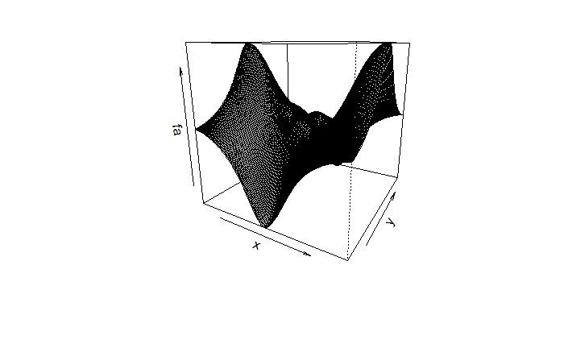

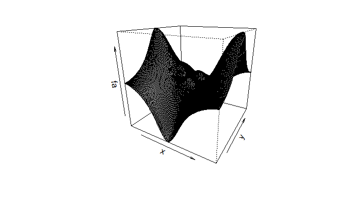

### Indexing Data

We often wish to examine part of a set of data. Suppose that our data is stored in the matrix `A`.

```r
A <- matrix(1:16, 4, 4)
```

```r
A
```

```
     [,1] [,2] [,3] [,4]
[1,]    1    5    9   13
[2,]    2    6   10   14
[3,]    3    7   11   15
[4,]    4    8   12   16
```

Then typing `A[2, 3]` will select the element corresponding to the second row and the third column.

```r
A[2, 3]
```

[output not shown]

The first number after the open-bracket symbol `[` always refers to the row, and the second number always refer to the column. We can also select multiple rows and columns at a time, by providing vectors as the indices.

```r
A[c(1, 3), c(2, 4)]
```

```
     [,1] [,2]
[1,]    5   13
[2,]    7   15
```

```r
A[1:3, 2:4]
```

```
     [,1] [,2] [,3]
[1,]    5    9   13
[2,]    6   10   14
[3,]    7   11   15
```

```r
A[1:2, ]
```

```
     [,1] [,2] [,3] [,4]
[1,]    1    5    9   13
[2,]    2    6   10   14
```

```r
A[, 1:2]
```

```
     [,1] [,2]
[1,]    1    5
[2,]    2    6
[3,]    3    7
[4,]    4    8
```

```r
A[1, ]
```

```
[1]  1  5  9 13
```

The use of a negative sign `-` in the index tells `R` to keep all rows or columns except those indicated in the index.

```r
A[-c(1, 3), ]
```

```
     [,1] [,2] [,3] [,4]
[1,]    2    6   10   14
[2,]    4    8   12   16
```

The `dim()` functions outputs the number of rows followed by the number of columns of a given matrix.

```r
dim(A)
```

```
[1] 4 4
```

### Loading Data

We begin by loading in the `Auto` data set. This data is part of the `ISLR` library but to illustrate `data()` function will load it.

```r
library(ISLR)
```

```r
data("Auto")
```

|  | mpg | cylinders | displacement | horsepower | weight | acceleration | year | origin | name |
| --- | --- | --- | --- | --- | --- | --- | --- | --- | --- |
| 1 | 18 | 8 | 307 | 130 | 3504 | 12.0 | 70 | 1 | chevrolet chevelle malibu |
| 2 | 15 | 8 | 350 | 165 | 3693 | 11.5 | 70 | 1 | buick skylark 320 |
| 3 | 18 | 8 | 318 | 150 | 3436 | 11.0 | 70 | 1 | plymouth satellite |
| 4 | 16 | 8 | 304 | 150 | 3433 | 12.0 | 70 | 1 | amc rebel sst |
| 5 | 17 | 8 | 302 | 140 | 3449 | 10.5 | 70 | 1 | ford torino |
| 6 | 15 | 8 | 429 | 198 | 4341 | 10.0 | 70 | 1 | ford galaxie 500 |

```r
dim(Auto)
```

```
[1] 392   9
```

We can use `names()` to check the variable names.

```r
names(Auto)
```

```
[1] "mpg"          "cylinders"    "displacement" "horsepower"   "weight"       "acceleration"
[7] "year"         "origin"       "name"
```

### Additional Graphical and Numerical Summaries

We can use the `plot()` function to produce **scatterplots** of the quantitative variables. However, simply typing the variable names will produce an error message, because `R` does not know to look in the `Auto` data set for those variables.

To refer to a variable, we must type the data set and the variable name joined with a `$` symbol. Alternatively, we can use the `attach()` function in order to tell `R` to make the variables in this data frame available by name.

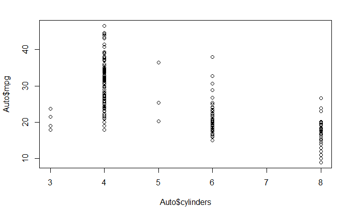

```r
attach(Auto)
```

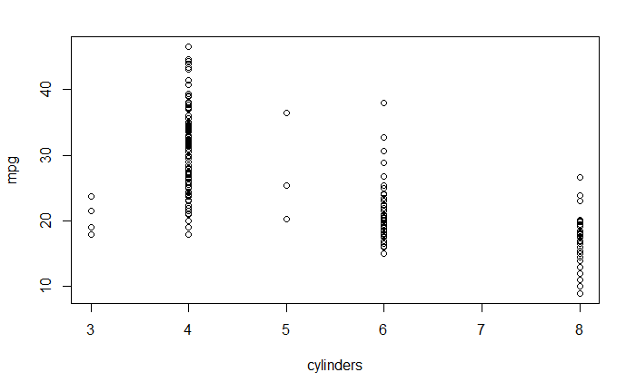

The `cylinders` variable is stored as a numeric vector, `R` has treated it as quantitative. However, since there are only a small number of possible values for `cylinders`, one may prefer to treat it as a qualitative variable.

The `as,factor()` function converts quantitative variables into qualitative variables.

```r
cylinders <- as.factor(cylinders)
```

If the variable plotted on the $x-axis$ is categorical, then **boxplots** will automatically be produced by the `plot()` function.

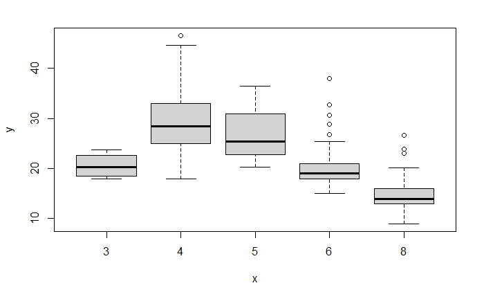

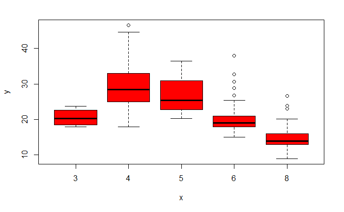

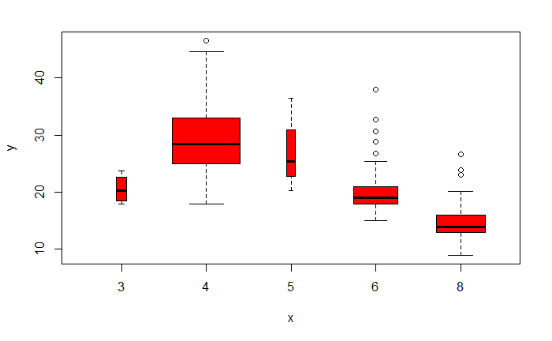

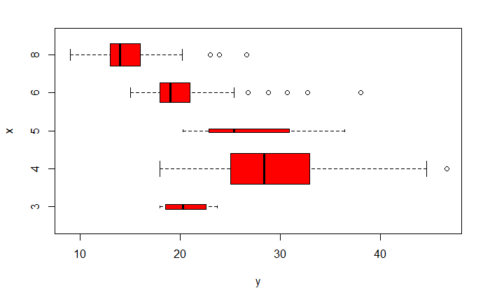

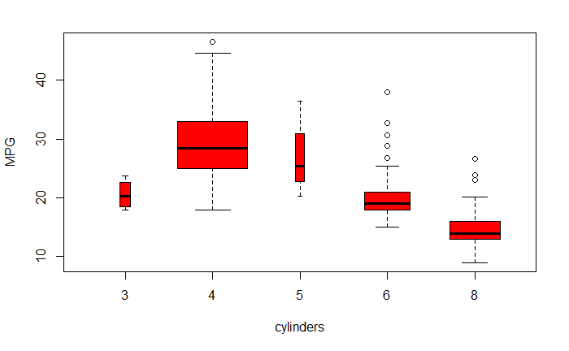

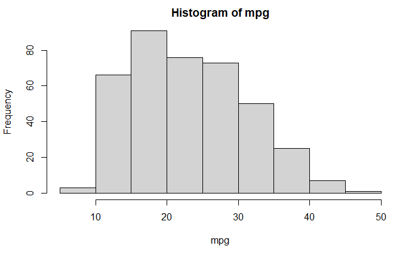

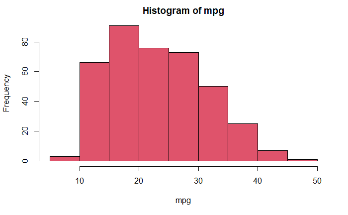

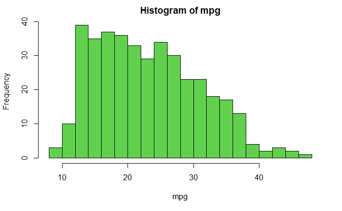

The `pairs()` function creates a **scatterplot matrix** for every pair of variables for any given data set. We can also produce scatterplots for just a subset of the variables.

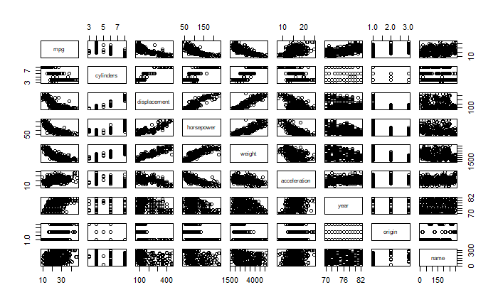

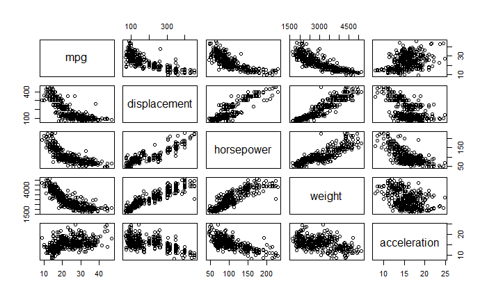

In conjunction with the `plot()` function, `identify()` provides a useful interactive method for identifying the value for a particular variable for points on a plot. We pass in three arguments to `identify():` the $x-axis$ variable, the $y-axis$ variable, and the variable whose values we would like to see printed for each point. The clicking on a given point in the plot will cause `R` to print the value of the variable of interest.

Right-clicking on the plot will exit the `identify()` function. The numbers printed under `identify()` function correspond to the rows for the selected points.

```
integer(0)
```

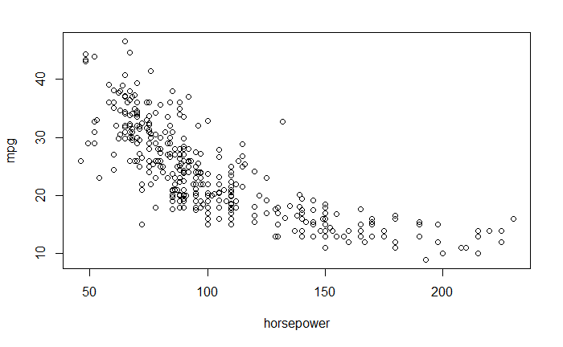

```r
{plot(horsepower, mpg);
identify(horsepower, mpg, name)}
```

The `summary()` function produces a numerical summary of each variable in a particular data set.

```r
summary(Auto)
```

```
      mpg          cylinders      displacement     horsepower        weight      acceleration
 Min.   : 9.00   Min.   :3.000   Min.   : 68.0   Min.   : 46.0   Min.   :1613   Min.   : 8.00
 1st Qu.:17.00   1st Qu.:4.000   1st Qu.:105.0   1st Qu.: 75.0   1st Qu.:2225   1st Qu.:13.78
 Median :22.75   Median :4.000   Median :151.0   Median : 93.5   Median :2804   Median :15.50
 Mean   :23.45   Mean   :5.472   Mean   :194.4   Mean   :104.5   Mean   :2978   Mean   :15.54
 3rd Qu.:29.00   3rd Qu.:8.000   3rd Qu.:275.8   3rd Qu.:126.0   3rd Qu.:3615   3rd Qu.:17.02
 Max.   :46.60   Max.   :8.000   Max.   :455.0   Max.   :230.0   Max.   :5140   Max.   :24.80

      year           origin                      name
 Min.   :70.00   Min.   :1.000   amc matador       :  5
 1st Qu.:73.00   1st Qu.:1.000   ford pinto        :  5
 Median :76.00   Median :1.000   toyota corolla    :  5
 Mean   :75.98   Mean   :1.577   amc gremlin       :  4
 3rd Qu.:79.00   3rd Qu.:2.000   amc hornet        :  4
 Max.   :82.00   Max.   :3.000   chevrolet chevette:  4
                                 (Other)           :365
```

We can also produce a summary of just a single variable.

```r
summary(mpg)
```

```
   Min. 1st Qu.  Median    Mean 3rd Qu.    Max.
   9.00   17.00   22.75   23.45   29.00   46.60
```

### Applied

This exercise relates to the `College` data set, which can be found in the file `College.csv`. It contains a number of variable for 777 different universities and colleges in the US. The variable are:

- `Private`: Public/private indicator
- `Apps`: Number of applications received
- `Accept`: Number of applicants accepted
- `Enroll`: Number of new students enrolled
- `Top10perc`: New students from top 10% of high school class
- `Top25perc`: New students from top 25% of high school class
- `F.Undergrad`: Number of full-time undergraduates
- `P.Undergrad`: Number of part-time undergraduates
- `Outstate`: Out-of-state tuition
- `Room.Board`: Room and board costs
- `Books`: Estimated book costs
- `Personal`: Estimated personal spending
- `PhD`: Percent of faculty with Ph.D.’s
- `Terminal`: Percent of faculty with terminal degree
- `S.F Ratio`: Student/faculty ratio
- `perc.alumni`: Percent of alumni who donate
- `Expend`: Instructional expenditure per student
- `Grad.Rate`: Graduation rate

```r
College = read.csv('College.csv', header = T, na.strings = '?') +
fix(College)
```

```
Error in Ops.data.frame(read.csv("College.csv", header = T, na.strings = "?"),  :
  ‘+’ only defined for equally-sized data frames
```

Let’s to save the `rownames` column into another variable

```r
rownames(College)= College[,1]
```

```r
fix(College)
```

```r
rownames
```

[output not shown]

```r
fix(College)
```

Use the `summary()` function to produce a numerical summary of the variables in the data set

```r
detach(College)
```

```
Error in detach(College) : invalid 'name' argument
```

```r
summary(College)
```

```
   Private               Apps           Accept          Enroll       Top10perc       Top25perc
 Length:777         Min.   :   81   Min.   :   72   Min.   :  35   Min.   : 1.00   Min.   :  9.0
 Class :character   1st Qu.:  776   1st Qu.:  604   1st Qu.: 242   1st Qu.:15.00   1st Qu.: 41.0
 Mode  :character   Median : 1558   Median : 1110   Median : 434   Median :23.00   Median : 54.0
                    Mean   : 3002   Mean   : 2019   Mean   : 780   Mean   :27.56   Mean   : 55.8
                    3rd Qu.: 3624   3rd Qu.: 2424   3rd Qu.: 902   3rd Qu.:35.00   3rd Qu.: 69.0
                    Max.   :48094   Max.   :26330   Max.   :6392   Max.   :96.00   Max.   :100.0
  F.Undergrad     P.Undergrad         Outstate       Room.Board       Books           Personal
 Min.   :  139   Min.   :    1.0   Min.   : 2340   Min.   :1780   Min.   :  96.0   Min.   : 250
 1st Qu.:  992   1st Qu.:   95.0   1st Qu.: 7320   1st Qu.:3597   1st Qu.: 470.0   1st Qu.: 850
 Median : 1707   Median :  353.0   Median : 9990   Median :4200   Median : 500.0   Median :1200
 Mean   : 3700   Mean   :  855.3   Mean   :10441   Mean   :4358   Mean   : 549.4   Mean   :1341
 3rd Qu.: 4005   3rd Qu.:  967.0   3rd Qu.:12925   3rd Qu.:5050   3rd Qu.: 600.0   3rd Qu.:1700
 Max.   :31643   Max.   :21836.0   Max.   :21700   Max.   :8124   Max.   :2340.0   Max.   :6800
      PhD            Terminal       S.F.Ratio      perc.alumni        Expend        Grad.Rate
 Min.   :  8.00   Min.   : 24.0   Min.   : 2.50   Min.   : 0.00   Min.   : 3186   Min.   : 10.00
 1st Qu.: 62.00   1st Qu.: 71.0   1st Qu.:11.50   1st Qu.:13.00   1st Qu.: 6751   1st Qu.: 53.00
 Median : 75.00   Median : 82.0   Median :13.60   Median :21.00   Median : 8377   Median : 65.00
 Mean   : 72.66   Mean   : 79.7   Mean   :14.09   Mean   :22.74   Mean   : 9660   Mean   : 65.46
 3rd Qu.: 85.00   3rd Qu.: 92.0   3rd Qu.:16.50   3rd Qu.:31.00   3rd Qu.:10830   3rd Qu.: 78.00
 Max.   :103.00   Max.   :100.0   Max.   :39.80   Max.   :64.00   Max.   :56233   Max.   :118.00
```

Use the `pairs()` function to produce a scatterplot matrix of the first ten columns or variables of the data. Recall that you can reference the first ten columns of a matrix `A` using `A[, 1:10]`.

```r
Private <- as.factor(Private)
```

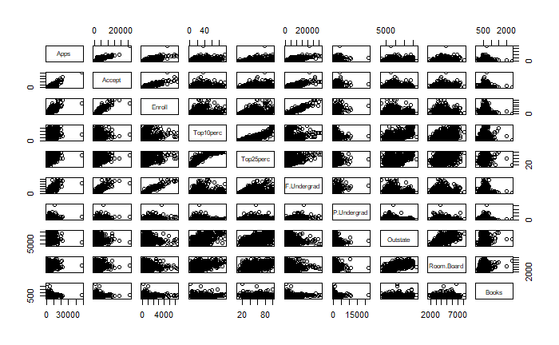

Use the `plot()` function to produce side-by-side boxplots of `Outstate` vs `Private`

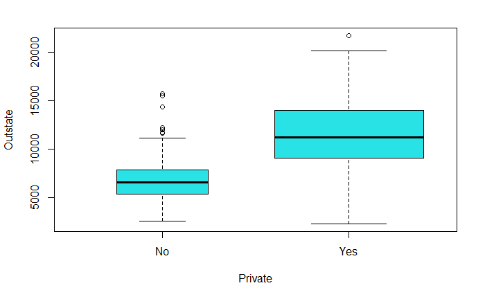

Create a new qualitative variable, called `Elite`, by **binning** the `Top10perc` variable. We are going to divide universities into two groups based on whether or not the proportion of students coming from the top 10% of their high school classes exceeds 50%.

```r
Elite <- rep('No', nrow(college))
```

```
Error in nrow(college) : object 'college' not found
```

```r
Elite[Top10perc > 50] = 'Yes'
```

```r
College <- data.frame(College, Elite)
```

```r
College$Elite <- as.factor(College$Elite)
```

```r
detach(College)
```

```r
print(College$Private)
```

[output not shown]

[output cut: 34 more lines]

```r
rm(Private)
```

```r
rm(Elite)
```

```r
detach(College)
```

```
Error in detach(College) : invalid 'name' argument
```

Use the `summary()` function to see how many elite universities there are.

```r
summary(Elite)
```

```
 No Yes
699  78
```

Now use `plot()` function to produce side-by-side boxplots of `Outstate` versus `Elite`.

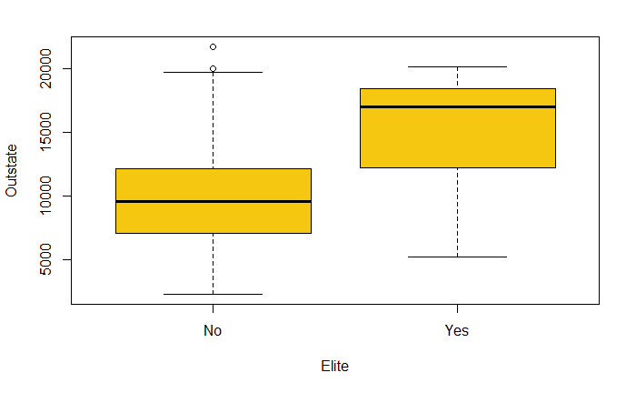

Use the `hist()` function to produce some histograms with different number of bins for a few quantitatives variables. You may find the command `par(mfrow=c(2,2))` useful: it will divide the print window into four regions so that four plots can be made simultaneously.

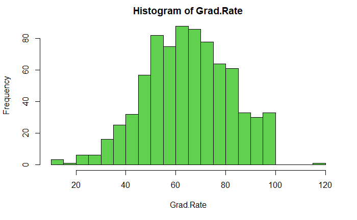

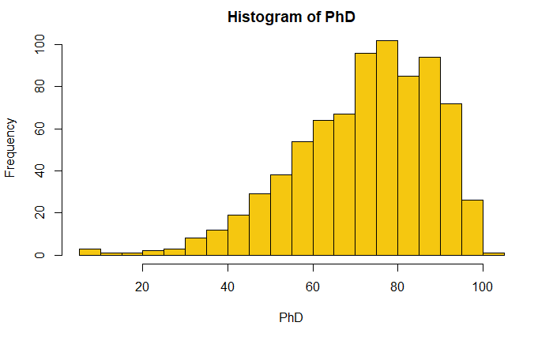

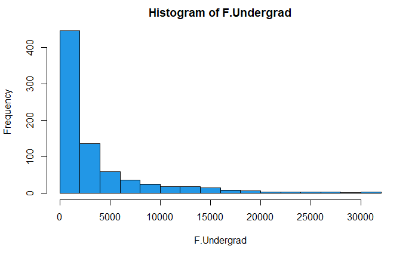

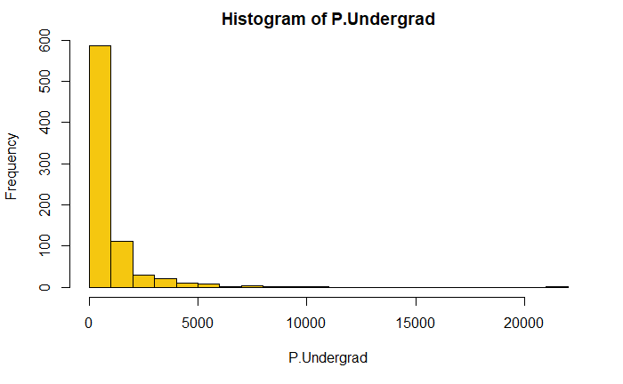

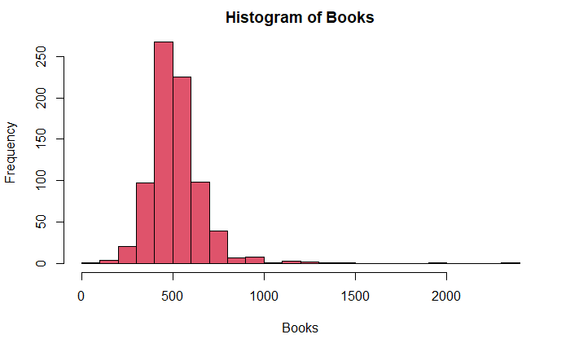

This exercise involves the `Auto` data set studied in the lab. Make sure that the missing values have been removed from the data.

```r
library(ISLR)
```

```r
dim(Auto)
```

```
[1] 392   9
```

1. Which of the predictors are quantitative, and which are qualitative?

|  | mpg | cylinders | displacement | horsepower | weight | acceleration | year | origin | name |
| --- | --- | --- | --- | --- | --- | --- | --- | --- | --- |
| 1 | 18 | 8 | 307 | 130 | 3504 | 12.0 | 70 | 1 | chevrolet chevelle malibu |
| 2 | 15 | 8 | 350 | 165 | 3693 | 11.5 | 70 | 1 | buick skylark 320 |
| 3 | 18 | 8 | 318 | 150 | 3436 | 11.0 | 70 | 1 | plymouth satellite |
| 4 | 16 | 8 | 304 | 150 | 3433 | 12.0 | 70 | 1 | amc rebel sst |
| 5 | 17 | 8 | 302 | 140 | 3449 | 10.5 | 70 | 1 | ford torino |
| 6 | 15 | 8 | 429 | 198 | 4341 | 10.0 | 70 | 1 | ford galaxie 500 |

The `str()` function show us the data type of each column in a data frame. However some columns could be categorical(qualitative) even though they have numeric data.

```r
str(Auto)
```

```
'data.frame':   392 obs. of  9 variables:
 $ mpg         : num  18 15 18 16 17 15 14 14 14 15 ...
 $ cylinders   : num  8 8 8 8 8 8 8 8 8 8 ...
 $ displacement: num  307 350 318 304 302 429 454 440 455 390 ...
 $ horsepower  : num  130 165 150 150 140 198 220 215 225 190 ...
 $ weight      : num  3504 3693 3436 3433 3449 ...
 $ acceleration: num  12 11.5 11 12 10.5 10 9 8.5 10 8.5 ...
 $ year        : num  70 70 70 70 70 70 70 70 70 70 ...
 $ origin      : num  1 1 1 1 1 1 1 1 1 1 ...
 $ name        : Factor w/ 304 levels "amc ambassador brougham",..: 49 36 231 14 161 141 54 223 241 2 ...
```

We can use the function `unique()` do determine which predictors we can consider as qualitative or categorical.

```r
apply(Auto, 2, unique)
```

```
$mpg
  [1] "18.0" "15.0" "16.0" "17.0" "14.0" "24.0" "22.0" "21.0" "27.0" "26.0" "25.0" "10.0" "11.0" " 9.0"
 [15] "28.0" "19.0" "12.0" "13.0" "23.0" "30.0" "31.0" "35.0" "20.0" "29.0" "32.0" "33.0" "17.5" "15.5"
 [29] "14.5" "22.5" "24.5" "18.5" "29.5" "26.5" "16.5" "31.5" "36.0" "25.5" "33.5" "20.5" "30.5" "21.5"
 [43] "43.1" "36.1" "32.8" "39.4" "19.9" "19.4" "20.2" "19.2" "25.1" "20.6" "20.8" "18.6" "18.1" "17.7"
 [57] "27.5" "27.2" "30.9" "21.1" "23.2" "23.8" "23.9" "20.3" "21.6" "16.2" "19.8" "22.3" "17.6" "18.2"
 [71] "16.9" "31.9" "34.1" "35.7" "27.4" "25.4" "34.2" "34.5" "31.8" "37.3" "28.4" "28.8" "26.8" "41.5"
 [85] "38.1" "32.1" "37.2" "26.4" "24.3" "19.1" "34.3" "29.8" "31.3" "37.0" "32.2" "46.6" "27.9" "40.8"
 [99] "44.3" "43.4" "36.4" "44.6" "33.8" "32.7" "23.7" "32.4" "26.6" "25.8" "23.5" "39.1" "39.0" "35.1"
[113] "32.3" "37.7" "34.7" "34.4" "29.9" "33.7" "32.9" "31.6" "28.1" "30.7" "24.2" "22.4" "34.0" "38.0"
[127] "44.0"

$cylinders
[1] "8" "4" "6" "3" "5"

```

[output cut: 211 more lines]

As we can see not only the predictor name but also predictors as cylinders, origin and year we could consider as qualitative.

2. What is the **range** of each quantitative predictor? You can answer this using the `range()` function.

For `mpg` predictor.

```r
range(mpg)
```

```
[1]  9.0 46.6
```

For `displacement` predictor

```r
range(displacement)
```

```
[1]  68 455
```

For `horsepower` predictor.

```r
range(horsepower)
```

```
[1]  46 230
```

For `weight` predictor.

```r
range(weight)
```

```
[1] 1613 5140
```

For `acceleration` predictor.

```r
range(acceleration)
```

```
[1]  8.0 24.8
```

3. What is the mean and standard deviation of each quantitative?

Let’s save in `qualitativeNames` predictors names that are factors

```r
qualitativeNames <- names(Auto)[sapply(Auto, is.factor]
```

```
Error: unexpected ']' in "qualitativeNames <- names(Auto)[sapply(Auto, is.factor]"
```

Also in `quantitativeNames` the predictors names of numeric type will be saved.

Now we can compute the mean with the `mean()` function

```r
sapply(Auto[, quantitativeNames], mean)
```

```
         mpg displacement   horsepower       weight acceleration
    23.44592    194.41199    104.46939   2977.58418     15.54133
```

And compute the standard deviation by using `sd()` function

```r
sapply(Auto[, quantitativeNames],sd)
```

```
         mpg displacement   horsepower       weight acceleration
    7.805007   104.644004    38.491160   849.402560     2.758864
```

4. Now remove the 10th through 85th observations. What is the range, mean, and standard deviation of each predictor in the subset of the data that remains.

```r
subset <- Auto[-10:85, ]
```

```
Error in xj[i] : only 0's may be mixed with negative subscripts
```

The range:

```r
sapply(subset[, quantitativeNames], range)
```

```
      mpg displacement horsepower weight acceleration
[1,] 11.0           68         46   1649          8.5
[2,] 46.6          455        230   4997         24.8
```

The mean:

```r
sapply(subset[, quantitativeNames], mean)
```

```
         mpg displacement   horsepower       weight acceleration
    24.36845    187.75394    100.95584   2939.64353     15.71830
```

The standard deviation:

```r
sapply(subset[, quantitativeNames], sd)
```

```
         mpg displacement   horsepower       weight acceleration
    7.880898    99.939488    35.895567   812.649629     2.693813
```

5. Using the full data set, investigate the predictors graphically, using **scatterplots** or other tools of your choice. Create some plots highlighting the relationships among the predictors. Comment on your findings.